# Tugas Besar FSD

Kevin Pratama Putra (18523064) / Rizqi Edining Wicaksono (18523117)

## Cancer Breast

Dataset yang kami gunakan untuk Tugas besar ini adalah tentang klasifikasi dari data-data yang ada seberapa berpengaruhnya data tersebut untuk mendiagnosis kankernya apakah ganas atau jinak.  
DataSet ini Didapat Dari Website : https://www.kaggle.com/uciml/breast-cancer-wisconsin-data.

```r
dataset <- read.csv("C:/data.csv" ,sep="," ,header=TRUE)
```

## Informasi Dataset

Dataset ini mempunyai 31 Yang dimana 1 nya adalah target variable yaitu “Diagnosis” Berikut adalah keterangan dari Target Variabel dan fitur yang ada pada dataset:

1.Diagnosis (M= Malignatn, B = Benign)

Sepuluh fitur yang bernilai untuk dihitung setiap jenisnya :

1. radius (ata-rata jarak dari pusat ke titik-titik pada garis keliling)
2. texture (deviasi standar dari nilai skala abu-abu)
3. perimeter
4. area
5. smoothness (variasi lokal dalam panjang radius)
6. compactness (keliling ^ 2 / luas - 1,0
7. concavity (tingkat keparahan bagian cekung dari kontur)
8. concave points (jumlah bagian cekung dari kontur)
9. symmetry
10. fractal dimension (“perkiraan garis pantai” - 1)

## Visualisasi Sebaran Data Menggunakan Histogram

Dibawah ini adalah 10 gambaran histogram dari sebaran data bagian mean

#### 1. Menampilkan histogram dari radius_mean yang ada di dataset

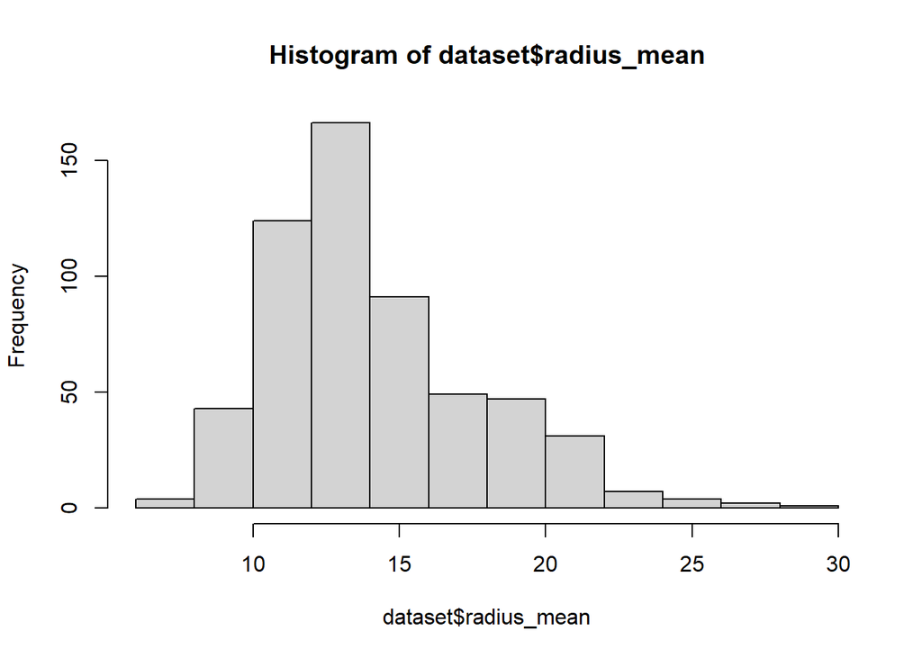

```r
hist(dataset$radius_mean)
```

#### 2. Menampilkan histogram dari texture_mean yang ada di dataset

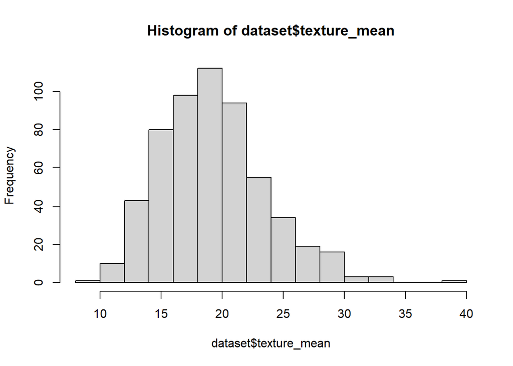

```r
hist(dataset$texture_mean)
```

#### 3. Menampilkan histogram dari perimeter_mean yang ada di dataset

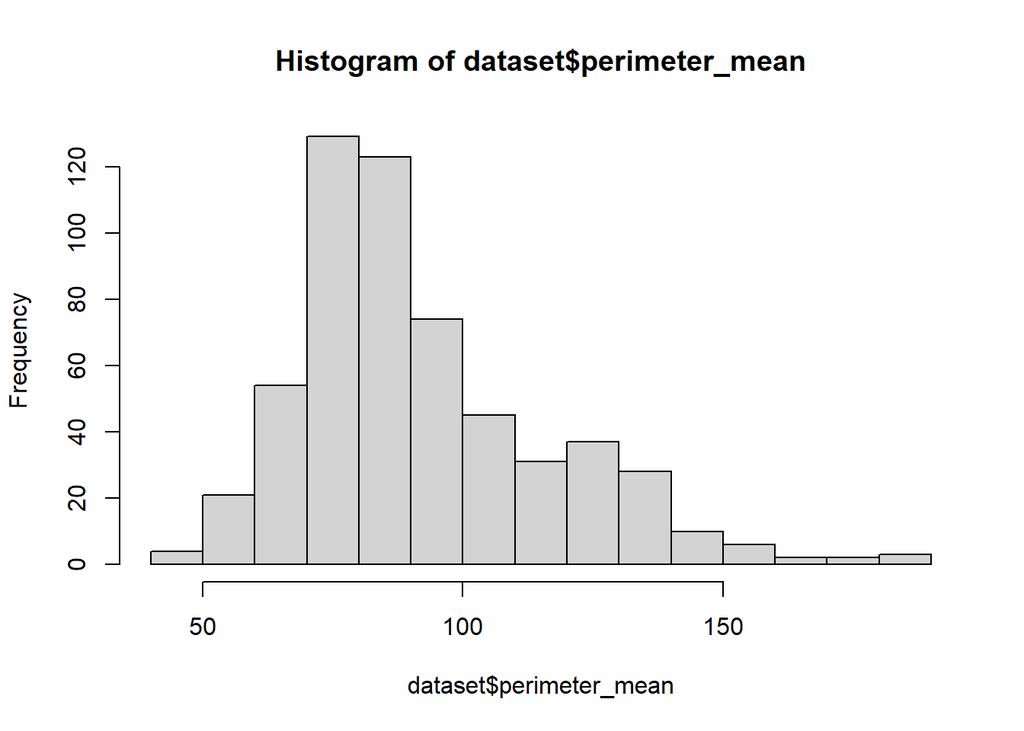

```r
hist(dataset$perimeter_mean)
```

#### 4. Menampilkan histogram dari area_mean yang ada di dataset

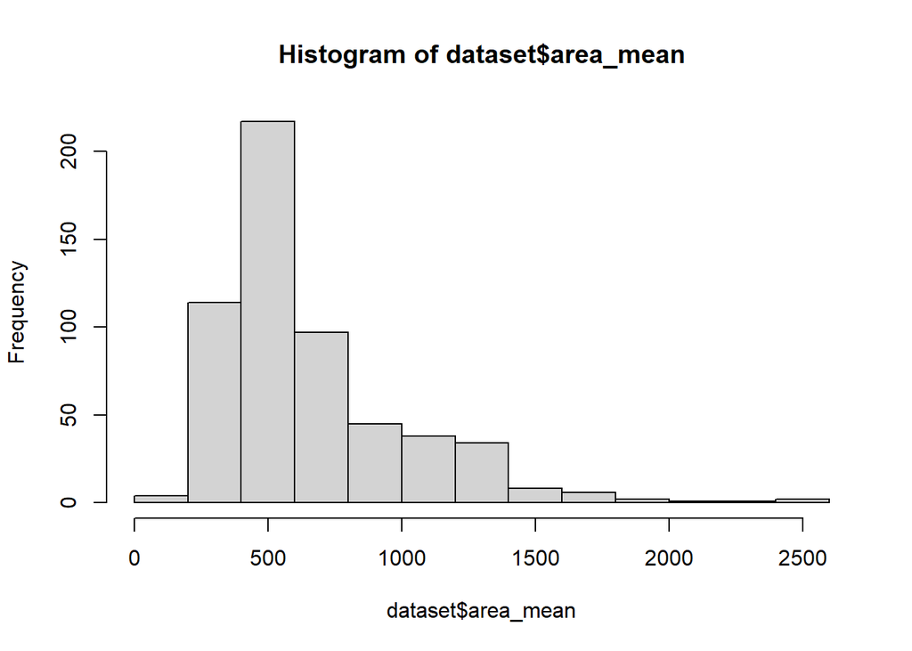

```r
hist(dataset$area_mean)
```

#### 5. Menampilkan histogram dari smoothness_mean yang ada di dataset

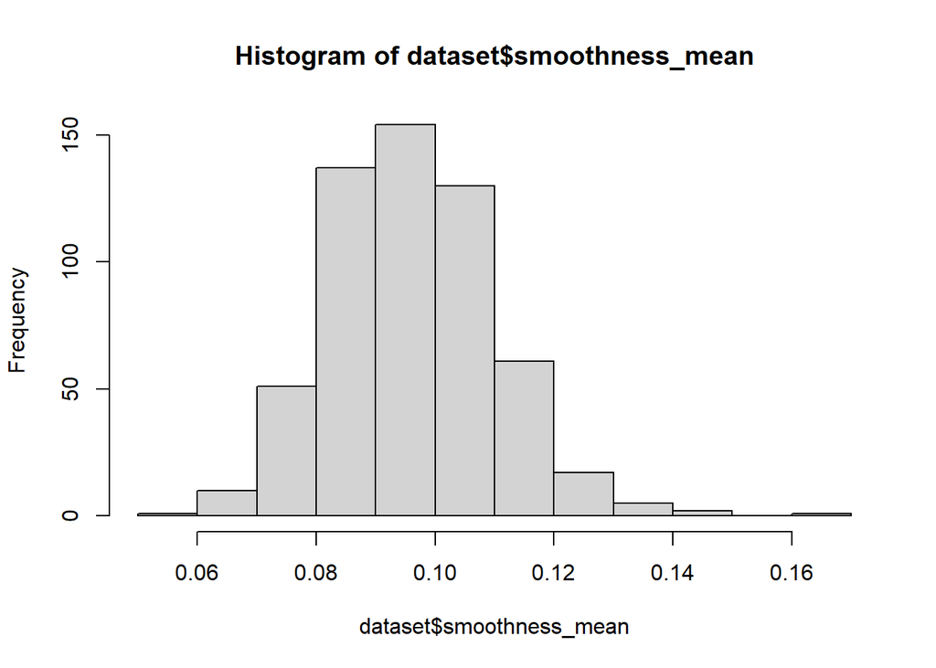

```r
hist(dataset$smoothness_mean)
```

#### 6. Menampilkan histogram dari compacness_mean yang ada di dataset

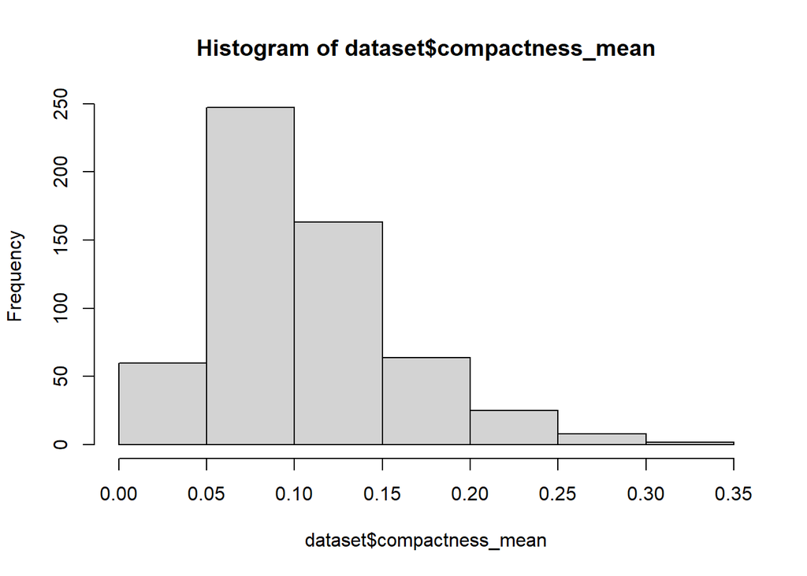

```r
hist(dataset$compactness_mean)
```

#### 7. Menampilkan histogram dari concavity_mean yang ada di dataset

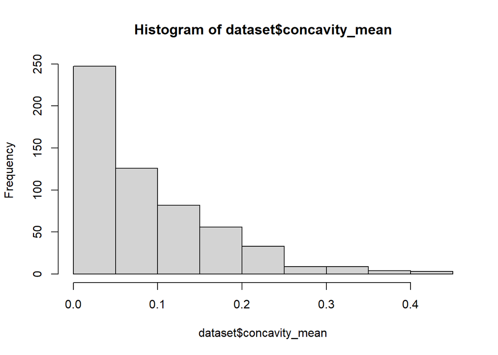

```r
hist(dataset$concavity_mean)
```

#### 8. Menampilkan histogram dari concave.points_mean yang ada di dataset

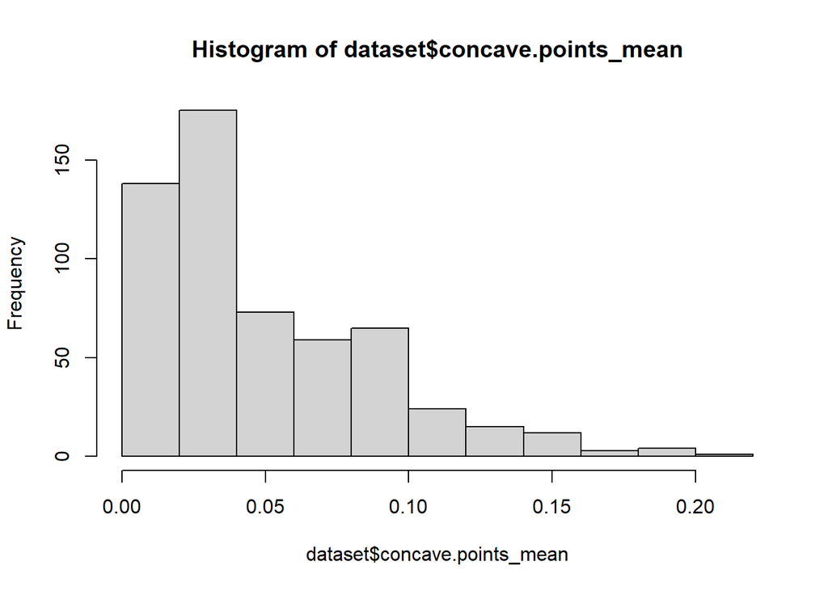

```r
hist(dataset$concave.points_mean)
```

#### 9. Menampilkan histogram dari symetry_mean yang ada di dataset

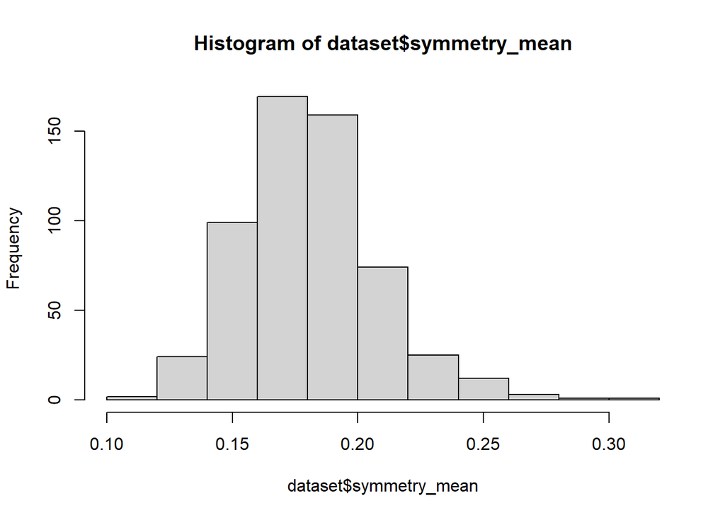

```r
hist(dataset$symmetry_mean)
```

#### 10.Menampilkan histogram dari dimension_mean yang ada di dataset

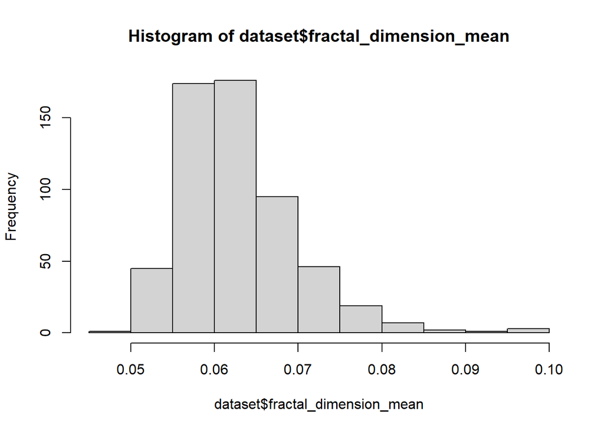

```r
hist(dataset$fractal_dimension_mean)
```

## 2.Pre Processing Data

```r
head(dataset)
```

```
##         id diagnosis radius_mean texture_mean perimeter_mean area_mean
## 1   842302         M       17.99        10.38         122.80    1001.0
## 2   842517         M       20.57        17.77         132.90    1326.0
## 3 84300903         M       19.69        21.25         130.00    1203.0
## 4 84348301         M       11.42        20.38          77.58     386.1
## 5 84358402         M       20.29        14.34         135.10    1297.0
## 6   843786         M       12.45        15.70          82.57     477.1
##   smoothness_mean compactness_mean concavity_mean concave.points_mean
## 1         0.11840          0.27760         0.3001             0.14710
## 2         0.08474          0.07864         0.0869             0.07017
## 3         0.10960          0.15990         0.1974             0.12790
## 4         0.14250          0.28390         0.2414             0.10520
## 5         0.10030          0.13280         0.1980             0.10430
## 6         0.12780          0.17000         0.1578             0.08089
##   symmetry_mean fractal_dimension_mean radius_se texture_se perimeter_se
```

[output cut: 34 more lines]

#### Encoding Categorical Pada Target Variable

Melakukan encoding categorical pada Target Variabel karena model Logistic regression hanya menerima input berupa data numerik maka dari itu Encoding categorical ini dibutuhkan untuk mengubah dari categorical menjadi data numerik.

```r
dataset$diagnosis = factor(dataset$diagnosis,
                           levels = c('M','B'),
                           labels = c(0,1))

table (dataset$diagnosis)
```

```
##
##   0   1
## 212 357
```

Dari gambar table diatas menunjukkan bahwa terdapat 212 Terdiagnosis Malignt(M) dan sebanyak 357 Benign(B)

```r
head(dataset)
```

```
##         id diagnosis radius_mean texture_mean perimeter_mean area_mean
## 1   842302         0       17.99        10.38         122.80    1001.0
## 2   842517         0       20.57        17.77         132.90    1326.0
## 3 84300903         0       19.69        21.25         130.00    1203.0
## 4 84348301         0       11.42        20.38          77.58     386.1
## 5 84358402         0       20.29        14.34         135.10    1297.0
## 6   843786         0       12.45        15.70          82.57     477.1
##   smoothness_mean compactness_mean concavity_mean concave.points_mean
## 1         0.11840          0.27760         0.3001             0.14710
## 2         0.08474          0.07864         0.0869             0.07017
## 3         0.10960          0.15990         0.1974             0.12790
## 4         0.14250          0.28390         0.2414             0.10520
## 5         0.10030          0.13280         0.1980             0.10430
## 6         0.12780          0.17000         0.1578             0.08089
##   symmetry_mean fractal_dimension_mean radius_se texture_se perimeter_se
```

[output cut: 34 more lines]

Pada fitur ‘id’ dan ‘X’ kompenen tidak dibutuhkan dalam mennentukan pemodelan sehingga perlu menghapus fitur ‘id’ dan ‘X’

```r
dataset$id <- NULL
dataset$X <- NULL
```

##### Memisahkan data set menjadi training set dan test set

Setelah melakukan penghapusan pada kompenen yang tidak diperlukan selanjutnya membagi dataset ‘training set’ dan ‘test set’ yang dimana ‘training set’ digunakan untuk melatih model dan ‘test set’ digunakan untuk mengvaluasi model yang digunakan

```r
library(caTools)

set.seed(123)
split = sample.split(dataset$diagnosis, SplitRatio=2/3)
#Training Set
training_set = subset(dataset, split == TRUE)
#Test_Set
test_set = subset(dataset, split == FALSE)
```

Berikut hasil dari dataset yang telah dipisah

```r
head(test_set)
```

```
##    diagnosis radius_mean texture_mean perimeter_mean area_mean smoothness_mean
## 2          0       20.57        17.77         132.90    1326.0         0.08474
## 4          0       11.42        20.38          77.58     386.1         0.14250
## 5          0       20.29        14.34         135.10    1297.0         0.10030
## 8          0       13.71        20.83          90.20     577.9         0.11890
## 11         0       16.02        23.24         102.70     797.8         0.08206
## 13         0       19.17        24.80         132.40    1123.0         0.09740
##    compactness_mean concavity_mean concave.points_mean symmetry_mean
## 2           0.07864        0.08690             0.07017        0.1812
## 4           0.28390        0.24140             0.10520        0.2597
## 5           0.13280        0.19800             0.10430        0.1809
## 8           0.16450        0.09366             0.05985        0.2196
## 11          0.06669        0.03299             0.03323        0.1528
## 13          0.24580        0.20650             0.11180        0.2397
##    fractal_dimension_mean radius_se texture_se perimeter_se area_se
```

[output cut: 34 more lines]

```r
head(training_set)
```

```
##    diagnosis radius_mean texture_mean perimeter_mean area_mean smoothness_mean
## 1          0       17.99        10.38         122.80    1001.0         0.11840
## 3          0       19.69        21.25         130.00    1203.0         0.10960
## 6          0       12.45        15.70          82.57     477.1         0.12780
## 7          0       18.25        19.98         119.60    1040.0         0.09463
## 9          0       13.00        21.82          87.50     519.8         0.12730
## 10         0       12.46        24.04          83.97     475.9         0.11860
##    compactness_mean concavity_mean concave.points_mean symmetry_mean
## 1            0.2776         0.3001             0.14710        0.2419
## 3            0.1599         0.1974             0.12790        0.2069
## 6            0.1700         0.1578             0.08089        0.2087
## 7            0.1090         0.1127             0.07400        0.1794
## 9            0.1932         0.1859             0.09353        0.2350
## 10           0.2396         0.2273             0.08543        0.2030
##    fractal_dimension_mean radius_se texture_se perimeter_se area_se
```

[output cut: 34 more lines]

## 3. Feature Scaling

Perlu dilakukan Scalling agar setiap fitur yang ada di ‘training_set’ dan ‘test_set’ nilainya sama sehingga satu fitur dan fitur lainnya tidak ada yang mendominasi

```r
training_set[, 2:31] = scale(training_set[, 2:31])
test_set[,2:31] = scale(test_set[, 2:31])
```

Berikut adalah Hasil Dari Scaling Dari Training_Set dan Test_Set yang dimana beberapa angkanya menjadi minus

```r
head(training_set)
```

```
##    diagnosis radius_mean texture_mean perimeter_mean  area_mean smoothness_mean
## 1          0   1.1135825   -2.0433636      1.2945684  0.9967531       1.6386291
## 3          0   1.6025085    0.4421338      1.5955487  1.5759976       0.9935065
## 6          0  -0.4797408   -0.8269104     -0.3871592 -0.5055545       2.3277372
## 7          0   1.1883594    0.1517399      1.1607993  1.1085875      -0.1039349
## 9          0  -0.3215589    0.5724681     -0.1810713 -0.3831103       2.2910825
## 10         0  -0.4768648    1.0800858     -0.3286353 -0.5089956       1.6532909
##    compactness_mean concavity_mean concave.points_mean symmetry_mean
## 1         3.4534883      2.7034314           2.6001712    2.28072154
## 3         1.1336053      1.3994839           2.0969158    0.97237680
## 6         1.3326777      0.8966960           0.8647263    1.03966310
## 7         0.1303594      0.3240764           0.6841310   -0.05560835
## 9         1.7899528      1.2534722           1.1960361    2.02279072
## 10        2.7045031      1.7791142           0.9837252    0.82658982
##    fractal_dimension_mean  radius_se texture_se perimeter_se    area_se
```

[output cut: 34 more lines]

```r
head(test_set)
```

```
##    diagnosis radius_mean texture_mean perimeter_mean  area_mean smoothness_mean
## 2          0   1.7720759   -0.3521545     1.62002931  1.8606497     -0.82226985
## 4          0  -0.7518558    0.2746704    -0.58427995 -0.7567842      3.05681637
## 5          0   1.6948409   -1.1759130     1.70769165  1.7798905      0.22271944
## 8          0  -0.1201833    0.3827437    -0.08141692 -0.2226594      1.47187117
## 11         0   0.5170060    0.9615361     0.41666453  0.3897182     -1.00225516
## 13         0   1.3859006    1.3361900     1.60010606  1.2953352      0.02795923
##    compactness_mean concavity_mean concave.points_mean symmetry_mean
## 2        -0.5223491    -0.06288424           0.4792747   -0.01769909
## 4         3.0998210     1.82788256           1.3529485    2.71220694
## 5         0.4333984     1.29675454           1.3305018   -0.02813185
## 8         0.9928001     0.01984445           0.2218864    1.31769443
## 11       -0.7332277    -0.72263336          -0.4420358   -1.00533388
## 13        2.4274801     1.40077731           1.5175573    2.01668948
##    fractal_dimension_mean  radius_se texture_se perimeter_se      area_se
```

[output cut: 34 more lines]

## 4. Melakukan pemodelan dengan Logistic Regression

Setelah melakukan scaling selanjutnya melakukan pelatihan terhadap model yang digunakan yaitu Logistic Regresstion pada data ‘training_set’

```r
classifier = glm(formula = diagnosis ~.,
                 family= binomial,
                 data = training_set)
```

## 5. Melakukan Evaluasi pada model Logistic Regresstion

Setelah melakukan pengujian pada model ‘training_set’ selanjutanya perlu dilakukan evaluasi pada model yang digunakan pada data **test_set** dengan memprekdisi data dari ‘test_set’

```r
prob_pred = predict(classifier, type = 'response', newdata = test_set[,2:31])
y_pred = ifelse(prob_pred > 0.5,1,0)
```

```r
head(prob_pred)
```

```
##            2            4            5            8           11           13
## 2.220446e-16 2.220446e-16 2.220446e-16 2.220446e-16 2.220446e-16 2.220446e-16
```

Selanjutnya membandingkan hasil prekdisi dengan hasil asli dari data ‘test_set’ menggunakan confusion matrix

```r
library(caret)
confusionMatrix(table(y_pred, test_set[,1]))
```

```
## Confusion Matrix and Statistics
##
##
## y_pred   0   1
##      0  64   6
##      1   7 113
##
##                Accuracy : 0.9316
##                  95% CI : (0.8858, 0.9631)
##     No Information Rate : 0.6263
##     P-Value [Acc > NIR] : <2e-16
##
##                   Kappa : 0.8534
##
##  Mcnemar's Test P-Value : 1
##
##             Sensitivity : 0.9014
##             Specificity : 0.9496
##          Pos Pred Value : 0.9143
##          Neg Pred Value : 0.9417
##              Prevalence : 0.3737
##          Detection Rate : 0.3368
##    Detection Prevalence : 0.3684
##       Balanced Accuracy : 0.9255
##
##        'Positive' Class : 0
##
```

‘confusion matrix’ diatas menjelaskan bahwa dengan model logistic regression berhasil memprediksi ‘dataset$diagnosis’ dengan ‘test_set’ dengan akurasi kesesuaian dengan ‘dataset’ aslinya sebesar 93%